# Midterm HW

통계 1714615 김승주

##1. Cheongpa2 자료를 활용하여 최근 7일간 체류인구로부터 내일의 체류인구를 예측한다.

** 목표  
- 예측을 위한 지도학습 모형 구축의 전 과정을 구현하기 ( 훈련, 비교, 선택, 테스트 )

### 문제 해결을 위한 라이브러리 불러오기

```r
library(class)
library(FNN)
library(glmnet)
```

```r
library(ggplot2)
```

### 데이터 불러오기

```r
load("Cheongpa2.Rdata")
head(Cheongpa2)
```

```
##         Date Today  Lag1  Lag2  Lag3  Lag4  Lag5  Lag6  Lag7
## 1 2018-12-08 19785 26437 27519 27105 26583 26618 22751 24606
## 2 2018-12-09 20630 19785 26437 27519 27105 26583 26618 22751
## 3 2018-12-10 26257 20630 19785 26437 27519 27105 26583 26618
## 4 2018-12-11 25284 26257 20630 19785 26437 27519 27105 26583
## 5 2018-12-12 25862 25284 26257 20630 19785 26437 27519 27105
## 6 2018-12-13 25054 25862 25284 26257 20630 19785 26437 27519
```

### 데이터 설명

```r
sum(is.null(Cheongpa2))
```

```
## [1] 0
```

```r
sum(is.na(Cheongpa2))
```

```
## [1] 0
```

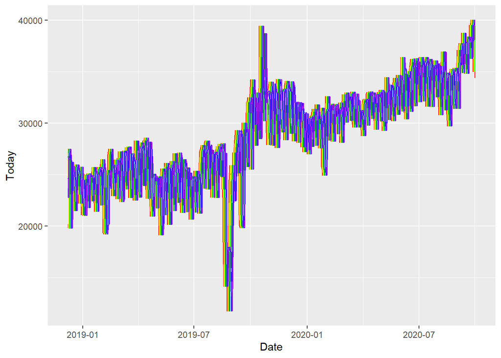

```r
ggplot(data = Cheongpa2) +
  geom_line(aes(x = Date, y = Today), color="red") +
  geom_line(aes(x = Date, y = Lag1), color="yellow") +
  geom_line(aes(x = Date, y = Lag2), color="gold") +
  geom_line(aes(x = Date, y = Lag3), color="green") +
  geom_line(aes(x = Date, y = Lag4), color="darkgreen") +
  geom_line(aes(x = Date, y = Lag5), color="skyblue") +
  geom_line(aes(x = Date, y = Lag6), color="blue") +
  geom_line(aes(x = Date, y = Lag7), color="purple")
```

2018년 12월 데이터와 2019년 데이터를 한 그룹으로 2020년 데이터를 하나의 그룹으로 묶어 시계열 데이터를 보았을 때 다음과 같다

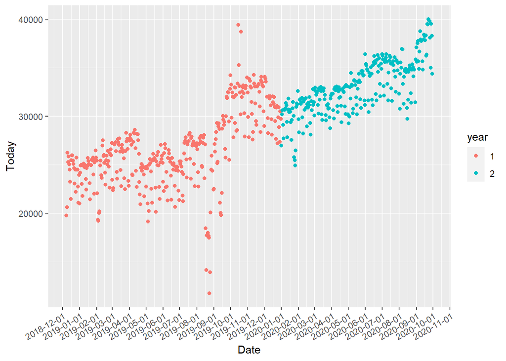

```r
data_year = Cheongpa2
data_year$year = ifelse(as.character(data_year$Date, "%Y") == 2020, "2", "1")
breaks = seq(as.Date("2018-12-01"),as.Date("2020-12-31"), by="1 month" )
ggplot(data = data_year, aes(x=Date)) + geom_point(data = data_year, aes(y=Today, color=year)) + scale_x_date(breaks = breaks) +theme(axis.text.x = element_text(angle=30, hjust=1))
```

2019년 8월 말의 데이터 3개가 현저히 낮은 값이며 2019-10월의 2개의 데이터가 상대적으로 큰 값을 지녀 이상값이라고 의심을 할 수 있다. 시계열 데이터의 outlier을 찾아주는 tsoutliers 패키지의 tsoutliers함수를 이용하여 이상치를 확인해 보도록 한다.

```r
library(fpp)
timeset=ts(Cheongpa2[,2], start = c(2018,12), frequency = 365.25) # 연간 계절성으로 이용
tsoutliers(timeset)
```

```
## $index
## [1] 254 260 261
##
## $replacements
## [1] 18093.50 18358.67 19212.33
```

```r
print(Cheongpa2[c(254,260,261),c(1,2)])
```

```
##           Date Today
## 254 2019-08-18 14136
## 260 2019-08-24 11745
## 261 2019-08-25 13908
```

이때 Lag1에서 Lag7값은 시차에 관한 데이터 값이므로 이를 주의하여 데이터값을 대체한다.

```r
data_re = Cheongpa2
for ( i in 1:8){
   data_re[c(254+(i-1),260+(i-1),261+(i-1)),i+1] = c(18093.50, 18358.67, 19212.33)
}
```

### 데이터셋 나누기 (tr : val : te = 6:2:2)

- 위 데이터는 시간에 따른 시계열 데이터이므로 날짜의 흐름에 따른 훈련데이터,검증데이터, 학습데이터의 분할이 요구된다.

```r
x = model.matrix(Today~., data=data_re)[,-c(1,2)]
y = data_re$Today

tr = 0.6
va = 0.2
n = nrow(data_re)

x.train = x[1 : floor(n*tr),]
y.train = y[1 : floor(n*tr)]
x.val = x[(floor(n*tr) + 1 ) : floor(n*(tr + va)), ]
y.val = y[(floor(n*tr) + 1 ) : floor(n*(tr + va)) ]
x.test = x[(floor(n*(tr + va)) + 1 ): n,]
y.test = y[(floor(n*(tr + va)) + 1 ) : n]
```

### 5개 모형과 3가지 오류측도 with validation data set (RMSE, MAE, MAPE)

- 3가지 오류측도는 시계열 데이터임을 감안하여 RMSE, MAE, MAPE로 지정하였다.
- $RMSE = \sqrt{MSE}$ $MAE = ave(|y-\widehat{y}|)$ $MAPE = ave(|\frac{y-\widehat{y}}{y}|)*100$
- 각 모형을 훈련데이터로 적합시키고 validation error가 가장 낮은 모형을 선택하여 각각의 오류 지표들을 비교한다.

#### (1) naive benchmark : y의 평균

```r
yhat.naive = mean(y.train)

rmse.naive = sqrt( mean( (y.val-yhat.naive)^2 ) )
mae.naive = mean( abs( y.val-yhat.naive ) )
mape.naive = mean( abs( (y.val-yhat.naive)/y.val) )*100

val.err.naive = c(rmse.naive, mae.naive, mape.naive )
```

#### (2) k-최근접이웃 regression

- K는 20으로 지정하였으며 1부터 20까지의 K를 적용하여 k-최근접이웃 모형을 적합하였다.

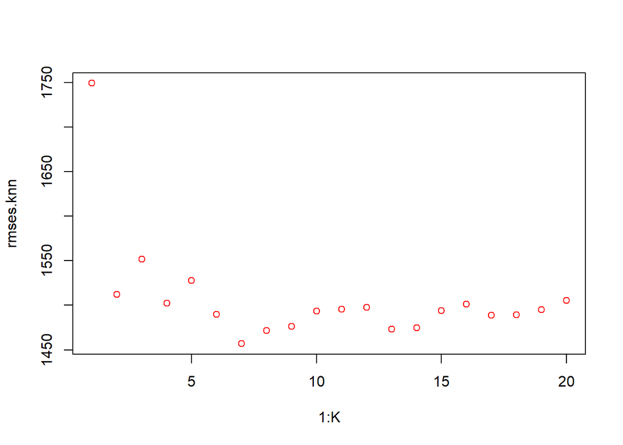

```r
K=20
rmses.knn = rep(NA,K)
maes.knn = rep(NA,K)
mapes.knn = rep(NA,K)
for (i in 1:K) {
  obj.knn = knn.reg(train = x.train, test = x.val, y = y.train, k=i)
  yhat.knn = obj.knn$pred
  rmses.knn[i] = sqrt(mean((y.val- yhat.knn)^2))
  maes.knn[i] = mean(abs(y.val-yhat.knn))
  mapes.knn[i] = mean(abs((y.val-yhat.knn)/y.val))*100
}
plot(x=1:K, y=rmses.knn, col='red')
```

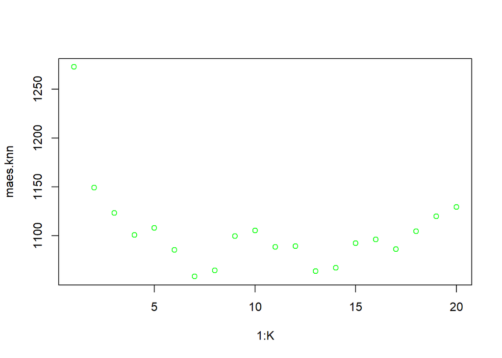

```r
plot(x=1:K, y=maes.knn, col='green')
```

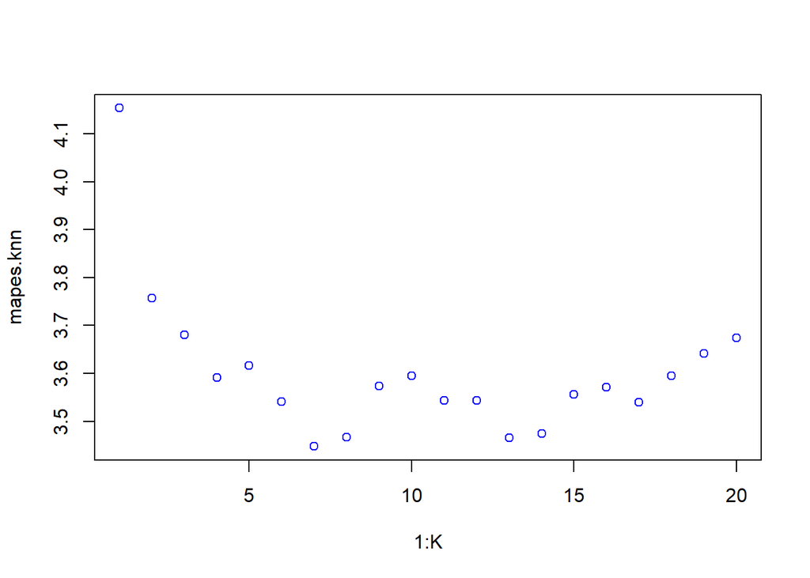

```r
plot(x=1:K, y=mapes.knn, col='blue')
```

```r
k.optimal.rmse = (1:K)[which.min(rmses.knn)]
k.optimal.mae = (1:K)[which.min(maes.knn)]
k.optimal.mape = (1:K)[which.min(mapes.knn)]
rmse.knn = rmses.knn[which.min(rmses.knn)]
mae.knn = maes.knn[which.min(maes.knn)]
mape.knn = mapes.knn[which.min(mapes.knn)]

val.err.knn =c( "RMSE.knn.7"=rmse.knn, "MAE.knn.7"=mae.knn, "MAPE.knn.7"=mape.knn  )
val.err.knn
```

```
##  RMSE.knn.7   MAE.knn.7  MAPE.knn.7
## 1456.986561 1058.577922    3.447807
```

- 위의 결과로 1부터 20까지의 K 중 세가지 오류측도모두가 가장 낮은 k=7을 선택하여 다른 모형들의 오류측도와 비교한다. 이때의 오류측도들은 위와 같다.

#### (3) 선형회귀

- 반응변수를 Today로 하여 Lag1~Lag7과 다중선형회귀모형으로 적합시킨다.

```r
obj.lm = lm(y.train ~ x.train)
yhat.lm = cbind(1,x.val)%*%coef(obj.lm)
rmse.lm = sqrt(mean((y.val-yhat.lm)^2))
mae.lm = mean(abs(y.val-yhat.lm))
mape.lm = mean(abs((y.val-yhat.lm)/y.val))*100

val.err.lm = c(rmse.lm, mae.lm, mape.lm )
```

#### (4) Ridge Regression

- 능형회귀의 하이퍼파라미터값인 람다값을 $2^{-30}$ 부터 $2^{30}$ 까지의 값을 100개의 등구간으로 나누어 고려한다.

```r
grid = 2^seq(from=30, to=-30, length=100)

obj.ridge = glmnet(x=x.train, y=y.train, family = "gaussian", alpha = 0, lambda = grid,standardize=T)
yhat.ridge = predict(obj.ridge, newx = x.val, type = "link")

rmses.ridge = apply(yhat.ridge, 2, function(x) sqrt(mean((y.val-x)^2)))
maes.ridge = apply(yhat.ridge, 2, function(x) mean(abs(y.val-x)))
mapes.ridge = apply(yhat.ridge, 2, function(x) mean(abs((y.val-x)/y.val))*100)

rmse.ridge = rmses.ridge[which.min(rmses.ridge)]
mae.ridge = maes.ridge[which.min(maes.ridge)]
mape.ridge = mapes.ridge[which.min(mapes.ridge)]
c("lambda.rmse"=grid[which.min(rmses.ridge)], "lambda.mae"=grid[which.min(maes.ridge)], "lambda.mape"=grid[which.min(mapes.ridge)])
```

```
##  lambda.rmse   lambda.mae  lambda.mape
## 1.534178e+01 9.313226e-10 9.313226e-10
```

- 람다에 대한 오류측도 시각화 그래프

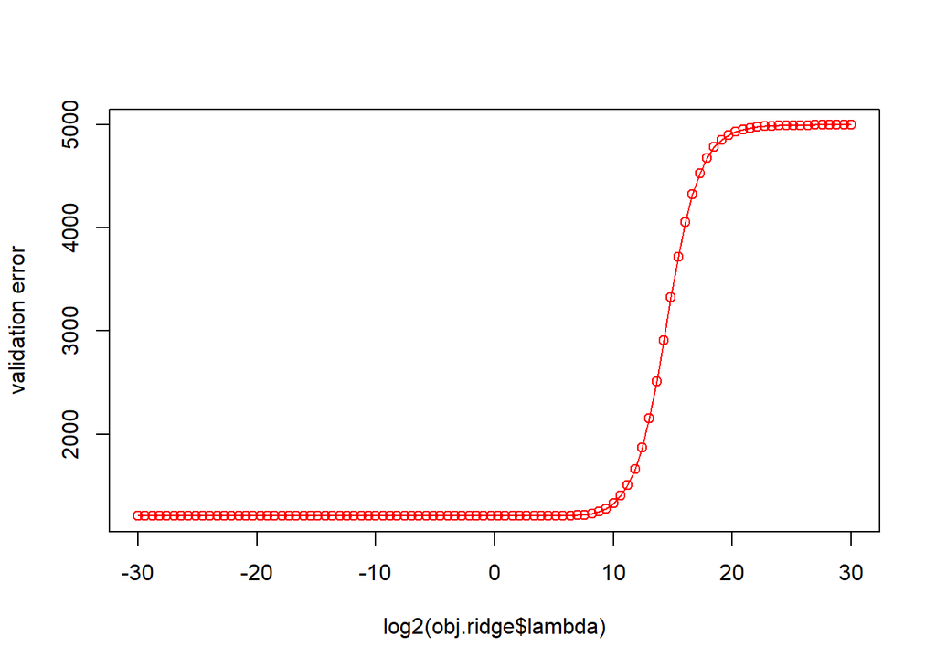

```r
plot(x=log2(obj.ridge$lambda), y=rmses.ridge,ylab='validation error',type="o",col="red")
```

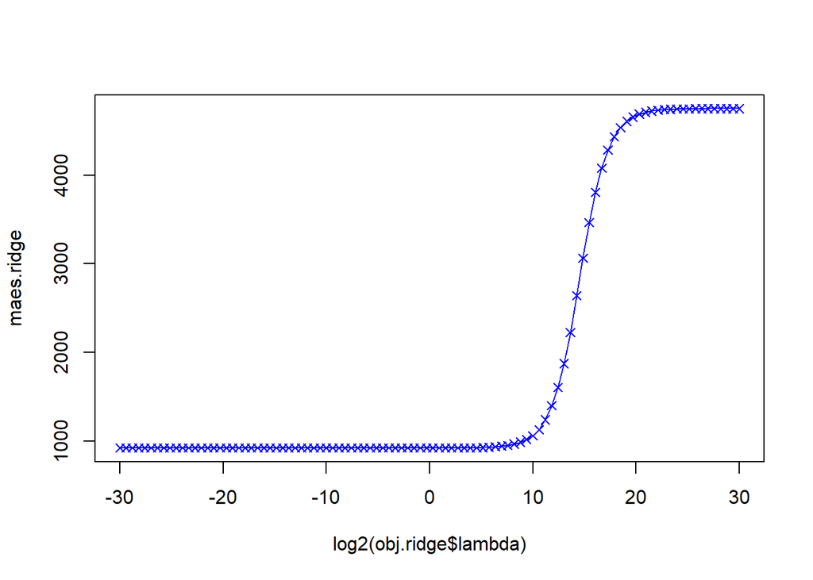

```r
plot(x=log2(obj.ridge$lambda), y=maes.ridge,pch=4,type="o",col="blue")
```

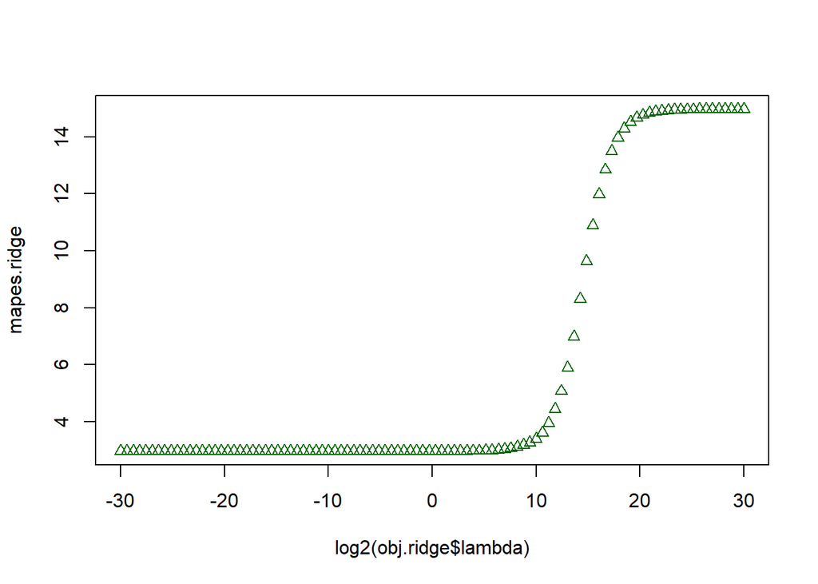

```r
plot(x=log2(obj.ridge$lambda), y=mapes.ridge,pch=2,col="darkgreen")
```

```r
val.err.ridge = c(rmses.ridge[100], mae.ridge, mape.ridge)
lambda.optimal.mse.ridge = grid[which.min(maes.ridge)]
yhat.ridge.opt = yhat.ridge[,which.min(maes.ridge)]
```

#### (5) Lasso Regression

```r
obj.lasso = glmnet( x=x.train, y=y.train, family="gaussian", alpha = 1, lambda = grid)
yhat.lasso = predict(obj.lasso, newx = x.val, type = "link")

rmses.lasso = apply(yhat.lasso, 2, function(x) sqrt(mean((y.val-x)^2)))
maes.lasso = apply(yhat.lasso, 2, function(x) mean(abs(y.val-x)))
mapes.lasso = apply(yhat.lasso, 2, function(x) mean(abs((y.val-x)/y.val))*100)

rmse.lasso = rmses.lasso[which.min(rmses.lasso)]
mae.lasso = maes.lasso[which.min(maes.lasso)]
mape.lasso = mapes.lasso[which.min(mapes.lasso)]
c("lambda.rmse"=grid[which.min(rmses.lasso)], "lambda.mae"=grid[which.min(maes.lasso)], "lambda.mape"=grid[which.min(mapes.lasso)])
```

```
##  lambda.rmse   lambda.mae  lambda.mape
## 3.498597e-01 9.313226e-10 2.192056e-07
```

- 람다에 대한 오류측도 시각화 그래프

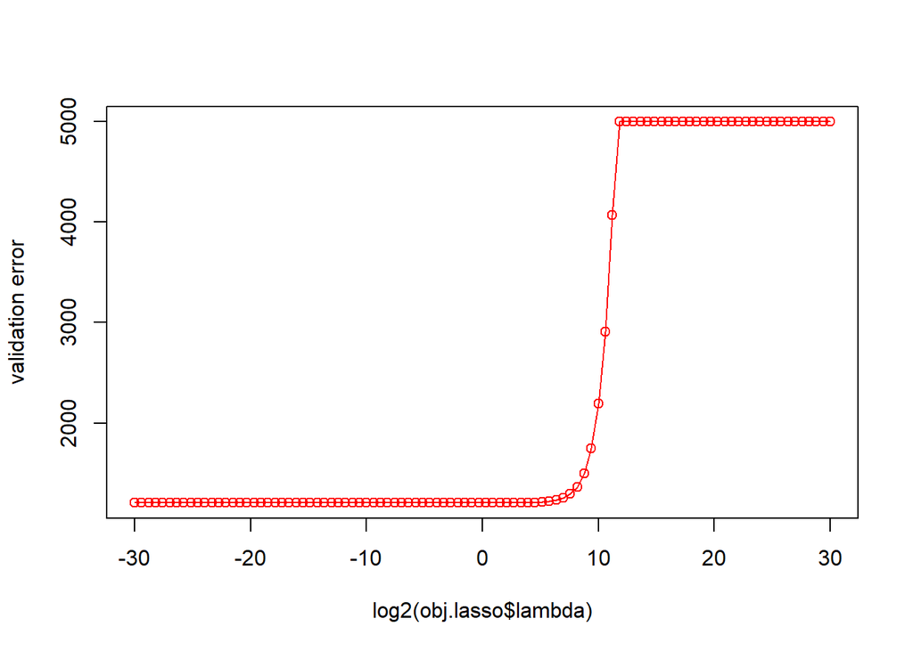

```r
plot(x=log2(obj.lasso$lambda), y=rmses.lasso,ylab='validation error',type="o",col="red")
```

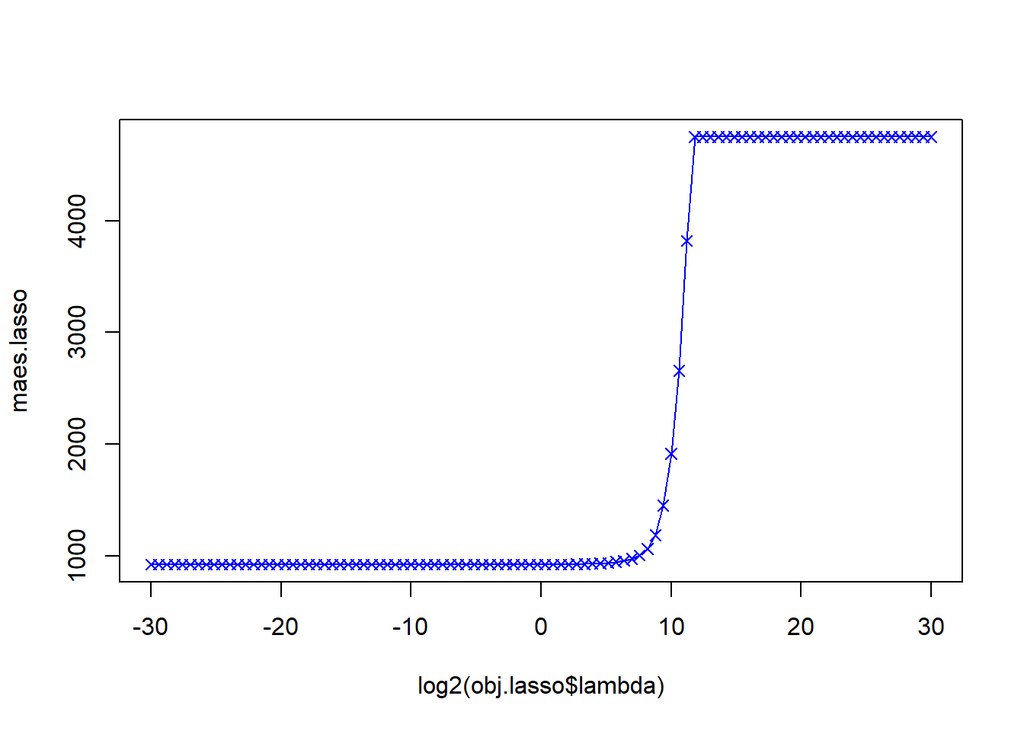

```r
plot(x=log2(obj.lasso$lambda), y=maes.lasso,pch=4,type="o",col="blue")
```

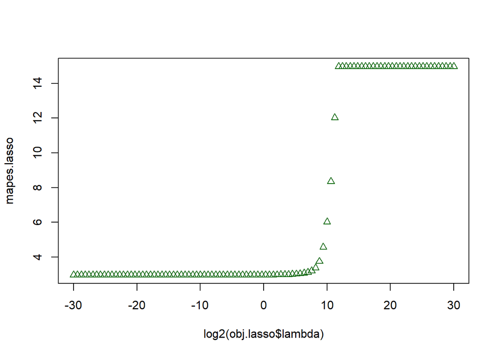

```r
plot(x=log2(obj.lasso$lambda), y=mapes.lasso,pch=2,col="darkgreen")
```

```r
val.err.lasso = c(rmses.lasso[100], mae.lasso, mapes.lasso[100])
lambda.optimal.lasso = grid[which.min(maes.lasso)]
yhat.lasso.opt = yhat.lasso[,which.min(maes.lasso)]
```

### 모형들의 검증세트오류 시각화

- 표 - <검증오류 비교>

```r
val.err.mat = data.frame(val.err.naive, val.err.knn, val.err.lm, val.err.ridge, val.err.lasso, row.names=c("RMSE","MAE", "MAPE"))
val.err.mat
```

```
##      val.err.naive val.err.knn  val.err.lm val.err.ridge val.err.lasso
## RMSE    4999.97957 1456.986561 1205.216513   1205.216513   1205.216514
## MAE     4752.22220 1058.577922  922.746034    922.746034    922.746034
## MAPE      14.96257    3.447807    2.973925      2.973925      2.973925
```

- $y_{validation}$ 과 $\widehat{y}_{validation}$ 의 시각화

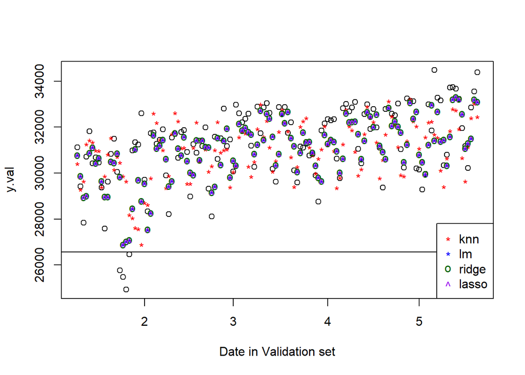

```r
plot(x=Cheongpa2$Date[(floor(n*tr) + 1 ) : floor(n*(tr + va))], y=y.val, xlab = "Date in Validation set")
abline(h=yhat.naive)
points(x=Cheongpa2$Date[(floor(n*tr) + 1 ) : floor(n*(tr + va))], y=yhat.knn, pch="*", col="red")
points(x=Cheongpa2$Date[(floor(n*tr) + 1 ) : floor(n*(tr + va))], y=yhat.lm, pch="*", col="blue")
points(x=Cheongpa2$Date[(floor(n*tr) + 1 ) : floor(n*(tr + va))], y=yhat.ridge.opt, pch="o", col="darkgreen")
points(x=Cheongpa2$Date[(floor(n*tr) + 1 ) : floor(n*(tr + va))], y=yhat.lasso.opt, pch="^", col="purple")
legend("bottomright", c( "knn", "lm", "ridge", "lasso") , col=c("red","blue","darkgreen","purple"), pch = c("*","*","o","^"))
```

### 최종모형의 선택 및 적합

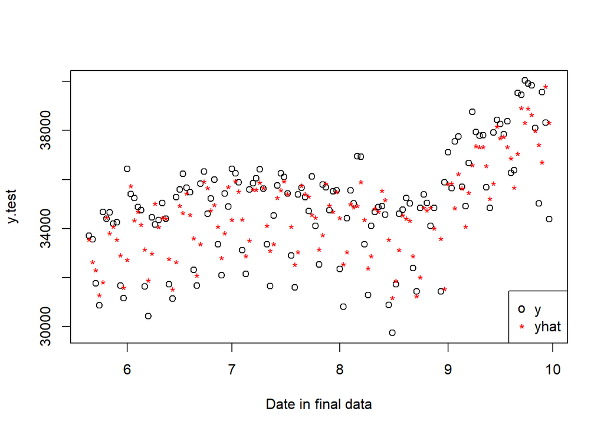

```r
x.final = rbind(x.train,x.val)
y.final = c(y.train, y.val)

obj.final.ridge = glmnet( x=x.final, y=y.final, family="gaussian", standardize = T, lambda = lambda.optimal.mse.ridge)
yhat.final.ridge = predict(obj.final.ridge, newx = x.test, type="link")

plot(x=Cheongpa2$Date[(length(y.final)+1):n], y=y.test, xlab = "Date in final data")
points(x=Cheongpa2$Date[(length(y.final)+1):n], y=yhat.final.ridge ,pch="*", col="red")
legend("bottomright", c( "y", "yhat") , col=c("black","red"), pch = c("o","*"))
```

** y 와 $\widehat{y}$ 의 시각화 그래프를 통해서도 잘 적합이 된 상태를 볼 수 있다.**